# Tutorial Exercise 3

Estimating False Discovery Rates in Strategy Development

Author

Barry Quinn

Published

March 4, 2025

```r
# Load required libraries
library(tidyverse)
library(ggplot2)
library(knitr)
library(kableExtra)
library(data.table)
```

## Introduction

In this tutorial, we will explore the problem of false discoveries in quantitative finance, specifically focusing on how multiple testing leads to selection bias in strategy development. We will:

1. Simulate the process of strategy development with random strategies
2. Calculate the impact of selection bias on Sharpe ratios
3. Implement the Deflated Sharpe Ratio (DSR) to correct for selection bias
4. Analyze how false discovery rates change with different parameters

This exercise will provide hands-on experience with the concepts discussed in the lecture on backtest overfitting.

## Part 1: Generating Random Strategies

Let’s first create a function to generate random strategy returns. These will simulate strategies with no genuine edge (i.e., the true Sharpe ratio is zero).

```r
# Function to generate random strategy returns
# This simulates the returns of investment strategies that have no real edge
generate_random_strategies <- function(n_strategies = 1000,
                                       n_returns = 252, # 252 trading days in a year
                                       mean_return = 0, # Zero expected return (no edge)
                                       sd_return = 0.01) { # 1% daily volatility is typical
  # Create a matrix of random returns drawn from a normal distribution
  # Each column represents a strategy, each row is a daily return
  returns_matrix <- matrix(
    rnorm(n_strategies * n_returns, mean = mean_return, sd = sd_return),
    nrow = n_returns,
    ncol = n_strategies
  )

  # Name each strategy for easier reference
  colnames(returns_matrix) <- paste0("Strategy_", 1:n_strategies)

  return(returns_matrix)
}

# Generate 1000 random strategies with 1 year of daily returns
# Using seed 42 ensures reproducibility - everyone gets the same random numbers
set.seed(42)
random_strategies <- generate_random_strategies(n_strategies = 1000,
                                              n_returns = 252)

# Check the dimensions to confirm we have 252 days × 1000 strategies
dim(random_strategies)
```

```
[1]  252 1000
```

Now, let’s calculate the Sharpe ratio for each of these strategies.

```r
# Function to calculate annualized Sharpe ratio
# The Sharpe ratio is the most common performance metric in finance
# It measures excess return per unit of risk (volatility)
calculate_sharpe <- function(returns, annualization_factor = 252) {
  # Calculate the mean daily return (this is our "signal")
  mean_return <- mean(returns)

  # Calculate the standard deviation of daily returns (this is our "noise")
  sd_return <- sd(returns)

  # Avoid division by zero (if we get a constant return series)
  if (sd_return == 0) return(0)

  # Calculate Sharpe ratio = signal/noise, then annualize
  # Annualization scales the daily Sharpe by sqrt(252) to get annual equivalent
  sharpe <- mean_return / sd_return * sqrt(annualization_factor)

  return(sharpe)
}

# Apply the Sharpe ratio calculation to each strategy (column)
# The "apply" function iterates through columns (2) of the matrix
sharpe_ratios <- apply(random_strategies, 2, calculate_sharpe)

# Examine the distribution statistics of these Sharpe ratios
# Even with random data, some strategies will appear to perform well!
summary(sharpe_ratios)
```

```
    Min.  1st Qu.   Median     Mean  3rd Qu.     Max.
-3.12341 -0.66761 -0.03249 -0.01905  0.62077  3.22375
```

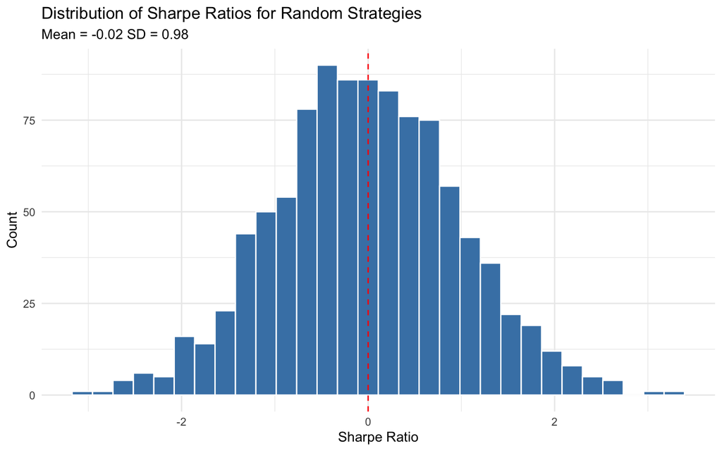

```r
# Visualize the distribution of Sharpe ratios
# This is a key visualization to understand the impact of randomness
tibble(Sharpe = sharpe_ratios) %>%
  ggplot(aes(x = Sharpe)) +
  geom_histogram(bins = 30, fill = "steelblue", color = "white") +
  labs(
    title = "Distribution of Sharpe Ratios for Random Strategies",
    subtitle = paste("Mean =", round(mean(sharpe_ratios), 2),
                    "SD =", round(sd(sharpe_ratios), 2)),
    x = "Sharpe Ratio",
    y = "Count"
  ) +
  theme_minimal() +
  # Add a vertical line at zero - the theoretical expectation for random strategies
  geom_vline(xintercept = 0, linetype = "dashed", color = "red")
```

The histogram above shows the distribution of Sharpe ratios for our 1,000 randomly generated strategies. This is a critical visualization that illustrates several important concepts in quantitative finance:

### Key Observations:

1. **Normal Distribution**: Notice how the Sharpe ratios follow an approximately normal distribution, centered near zero (mean = -0.02). This is exactly what we would expect when strategies have no genuine edge – their performance is purely random.
2. **Standard Deviation**: The standard deviation of 0.98 tells us about the spread of Sharpe ratios. This is crucial because it determines how impressive a “good” Sharpe ratio needs to be to stand out from random noise.
3. **Range of Values**: Even though these strategies are completely random (with no edge), we see Sharpe ratios ranging from approximately -3 to +3. In practical terms, a Sharpe ratio of +2 is typically considered excellent in the investment industry! Yet here we see several random strategies achieving this level purely by chance.

### Implications for Strategy Development:

This distribution demonstrates why statistical significance is so important in strategy evaluation. If you tested just one strategy and it showed a Sharpe ratio of 1.5, you might be excited about its performance. However, this chart shows that among 1,000 random strategies, we’d expect several to show Sharpe ratios of 1.5 or higher simply due to chance.

This is precisely why multiple testing is so dangerous in quantitative finance. When researchers or traders test many strategy variations and report only the best performer, they are essentially “selecting” from the right tail of this distribution – capturing lucky outcomes rather than genuine edge.

In the next sections, we’ll explore exactly how the maximum Sharpe ratio increases with the number of trials, and how we can use the Deflated Sharpe Ratio to correct for this selection bias.